# Hands-on Exercise 5d: Visual Multivariate Analysis with Parallel Coordinates Plot

Author

Andy Tai

Published

May 10, 2026

Modified

May 10, 2026

## 1 Overview

Parallel coordinates plots are designed for visualising multivariate numerical data. They allow multiple quantitative variables to be compared simultaneously, even when the variables have different ranges and measurement units.

## 2 Getting Started

**Install libraries**

For this exercise, the **GGally**, **parcoords**, **parallelPlot** and **tidyverse** packages will be used.

```r
pacman::p_load(GGally, parallelPlot, tidyverse)
```

**import data**

In this hands-on exercise, the data of [World Happiness 2018 report](https://www.worldhappiness.report/ed/2018/) will be used. The original data set is in Microsoft Excel format. It has been extracted and saved in csv file called **WHData-2018.csv**.

```r
library(janitor)

wh <- read_csv("data/WHData-2018.csv") %>%
  clean_names()

glimpse(wh)
```

```
Rows: 156
Columns: 12
$ country                      <chr> "Albania", "Bosnia and Herzegovina", "Bul…
$ region                       <chr> "Central and Eastern Europe", "Central an…
$ happiness_score              <dbl> 4.586, 5.129, 4.933, 5.321, 6.711, 5.739,…
$ whisker_high                 <dbl> 4.695, 5.224, 5.022, 5.398, 6.783, 5.815,…
$ whisker_low                  <dbl> 4.477, 5.035, 4.844, 5.244, 6.639, 5.663,…
$ dystopia                     <dbl> 1.462, 1.883, 1.219, 1.769, 2.494, 1.457,…
$ gdp_per_capita               <dbl> 0.916, 0.915, 1.054, 1.115, 1.233, 1.200,…
$ social_support               <dbl> 0.817, 1.078, 1.515, 1.161, 1.489, 1.532,…
$ healthy_life_expectancy      <dbl> 0.790, 0.758, 0.712, 0.737, 0.854, 0.737,…
$ freedom_to_make_life_choices <dbl> 0.419, 0.280, 0.359, 0.380, 0.543, 0.553,…
$ generosity                   <dbl> 0.149, 0.216, 0.064, 0.120, 0.064, 0.086,…
$ perceptions_of_corruption    <dbl> 0.032, 0.000, 0.009, 0.039, 0.034, 0.174,…
```

## 3 Static Parallel Coordinates Plot

**(a) basic plot**

The code chunk below plots a basic parallel coordinate plot.

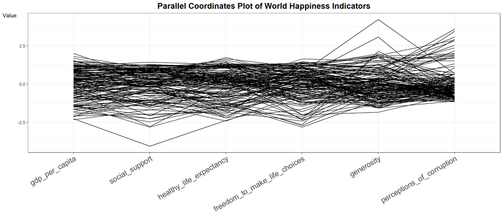

```r
ggparcoord(data    = wh,
           columns = c(7:12)) +
  labs(title = "Parallel Coordinates Plot of World Happiness Indicators") +
  xlab("Happiness Indicators") +
  ylab("Value") +
  theme_bw() +
  theme(
    plot.title   = element_text(hjust = 0.5, face = "bold", size = 16),
    axis.title.x = element_blank(),
    axis.title.y = element_text(hjust = 1, angle = 0),
    axis.text.x  = element_text(angle = 30, hjust = 1, size = 15),
    legend.text   = element_text(size = 12),    #<< bigger legend text
    legend.title  = element_text(size = 13)     #<< bigger legend title
  )
```

**(b) showPoints**

Here, we set `showPoints = TRUE` and `alphaLines = 0.3` are added to show individual observations and reduce opacity of the lines to reduce visual clutter.

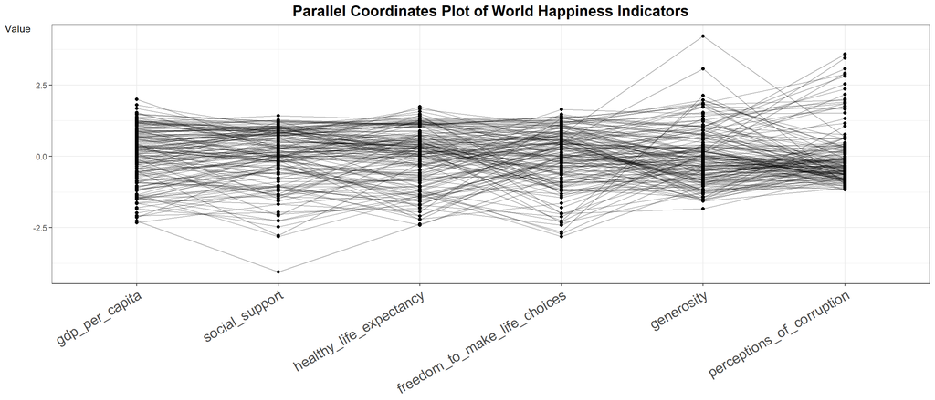

```r
ggparcoord(data    = wh,
           columns = c(7:12),
           showPoints = TRUE,
           alphaLines = 0.3
           ) +
  labs(title = "Parallel Coordinates Plot of World Happiness Indicators") +
  xlab("Happiness Indicators") +
  ylab("Value") +
  theme_bw() +
  theme(
    plot.title   = element_text(hjust = 0.5, face = "bold", size = 16),
    axis.title.x = element_blank(),
    axis.title.y = element_text(hjust = 1, angle = 0),
    axis.text.x  = element_text(angle = 30, hjust = 1, size = 15),
    legend.text   = element_text(size = 12),    #<< bigger legend text
    legend.title  = element_text(size = 13)     #<< bigger legend title
  )
```

**(c) groupColumn**

Here, we add `groupColumn = "Region"` groups to colour the observations by their Region.

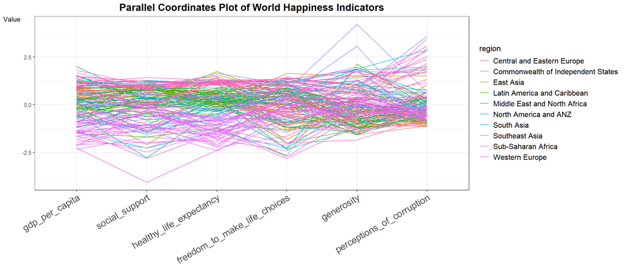

```r
ggparcoord(data    = wh,
           columns = c(7:12),
           groupColumn = "region"
           ) +
  labs(title = "Parallel Coordinates Plot of World Happiness Indicators") +
  xlab("Happiness Indicators") +
  ylab("Value") +
  theme_bw() +
  theme(
    plot.title   = element_text(hjust = 0.5, face = "bold", size = 16),
    axis.title.x = element_blank(),
    axis.title.y = element_text(hjust = 1, angle = 0),
    axis.text.x  = element_text(angle = 30, hjust = 1, size = 15),
    legend.text   = element_text(size = 12),    #<< bigger legend text
    legend.title  = element_text(size = 13)     #<< bigger legend title
  )
```

**(d) highlight**

The highlighting effect is performed manually by assigning a highlight colour via `scale_color_manual()` to the group of interest, while muting the colours of the other groups in the backdrop.

We use `gghighlight` to bring the highlighted lines to the front:

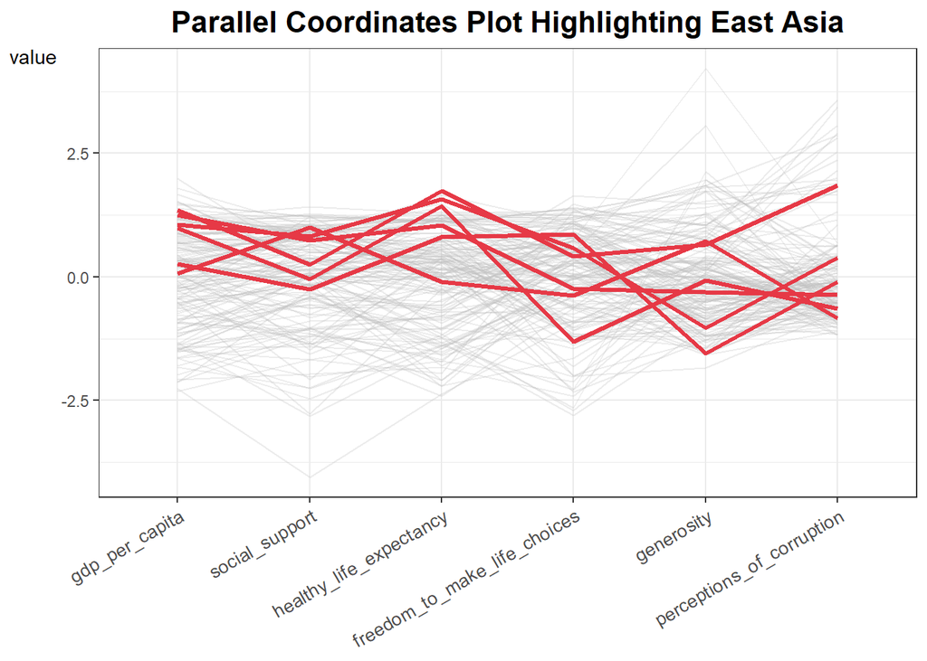

```r
library(gghighlight)

ggparcoord(data        = wh,
           columns     = c(7:12),
           groupColumn = "region",
           alphaLines  = 0.1) +                         #<< more transparent background
  gghighlight(region == "East Asia",
              use_direct_label = FALSE,
              unhighlighted_params = list(
                alpha     = 0.3,                        #<< fainter background lines
                linewidth = 0.5                         #<< thinner background lines
              )) +
  labs(title = "Parallel Coordinates Plot Highlighting East Asia") +
  scale_color_manual(values = c("East Asia" = "#E63946")) +
  theme_bw() +
  theme(
    plot.title      = element_text(hjust = 0.5, face = "bold", size = 16),
    axis.title.x    = element_blank(),
    axis.title.y    = element_text(hjust = 1, angle = 0),
    axis.text.x     = element_text(angle = 30, hjust = 1, size = 10),
    legend.position = "none"
  ) +
  geom_line(linewidth = 1.2)                            #<< thicker highlighted lines
```

**(e) boxplot**

Here, we We superimpose boxplots to the chart by setting `boxplot` argument to TRUE. The default is FALSE.

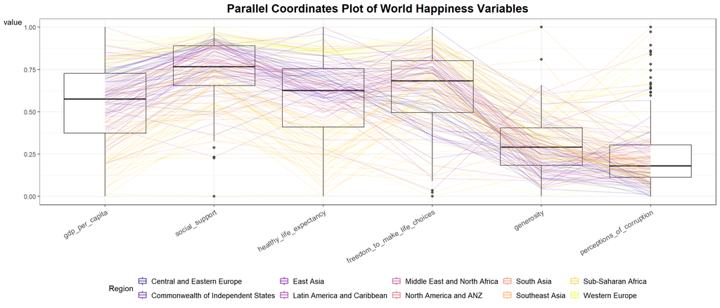

```r
ggparcoord(data        = wh,
           columns     = c(7:12),
           groupColumn = "region",              #<< named column instead of index
           scale       = "uniminmax",
           alphaLines  = 0.2,
           boxplot     = TRUE,
           title       = "Parallel Coordinates Plot of World Happiness Variables") +
  scale_color_viridis_d(option = "plasma",      #<< better colours per region
                        name   = "Region") +
  theme_bw() +
  theme(
    plot.title       = element_text(hjust = 0.5, face = "bold", size = 16),
    axis.title.x     = element_blank(),
    axis.title.y     = element_text(hjust = 1, angle = 0),
    axis.text.x      = element_text(angle = 30, hjust = 1, size = 10),
    legend.position  = "bottom",
    legend.text      = element_text(size = 10),
    legend.title     = element_text(size = 11),
    legend.key.size  = unit(0.5, "cm")
  )
```

**(f) facet**

Since `ggparcoord()` is developed by extending **ggplot2** package, we can combination use some of the ggplot2 function when plotting a parallel coordinates plot.

In the code chunk below, `facet_wrap()` of **ggplot2** is used to plot 10 small multiple parallel coordinates plots. Each plot represent one geographical region such as East Asia.

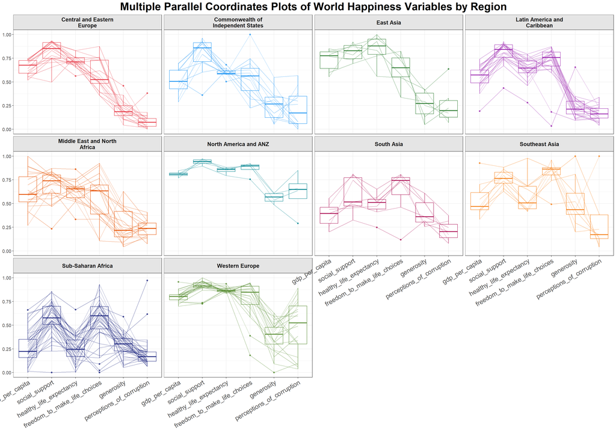

```r
ggparcoord(data        = wh,
           columns     = c(7:12),
           groupColumn = "region",
           scale       = "uniminmax",
           alphaLines  = 0.5,
           boxplot     = TRUE,
           title       = "Multiple Parallel Coordinates Plots of World Happiness Variables by Region") +
  facet_wrap(~ region,
             labeller = labeller(region = label_wrap_gen(width = 25))) +
  scale_color_manual(values = c(
    "#E63946",   # red
    "#2196F3",   # blue
    "#2E7D32",   # dark green
    "#9C27B0",   # purple
    "#E65100",   # dark orange
    "#00838F",   # teal
    "#AD1457",   # dark pink
    "#F57F17",   # amber
    "#1A237E",   # dark navy
    "#558B2F"    # olive green
  )) +
  theme_bw() +
  theme(
    plot.title       = element_text(hjust = 0.5, face = "bold", size = 25),
    axis.title.x     = element_blank(),
    axis.title.y     = element_blank(),
    axis.text.x      = element_text(angle = 30, hjust = 1, size = 15),
    axis.text.y      = element_text(size = 11),
    strip.text       = element_text(size = 13, face = "bold"),
    strip.background = element_rect(fill = "grey90"),
    legend.position  = "none"
  )
```

## 4 Interactive Parallel Coordinates Plot

**(a) basic parallelPlot**

- Click on a variable of interest, for example Happiness score, the monotonous blue colour (default) will change a blues with different intensity colour scheme will be used.
- Hover over observation of interest to highlight its trajectory across variables.

```r
wh_selected <- wh %>%
  select(happiness_score, gdp_per_capita, social_support,
         healthy_life_expectancy, freedom_to_make_life_choices,
         generosity, perceptions_of_corruption)

parallelPlot(wh_selected,
             width       = 600,
             height      = 400,
             rotateTitle = TRUE)
```

[interactive chart not shown]

**(b) histoVisibility**

In the code chunk below, `histoVisibility` argument is used to plot histogram along the axis of each variables.

```r
histoVisibility <- rep(TRUE, ncol(wh_selected))

parallelPlot(wh_selected,
             width           = 600,
             height          = 400,
             rotateTitle     = TRUE,
             histoVisibility = histoVisibility)
```

[interactive chart not shown]

## 5 References

- Kam, T.S. (2023). [Visual Multivariate Analysis with Parallel Coordinates Plot](https://r4va.netlify.app/chap15).
- [ggparcoord()](https://ggobi.github.io/ggally/reference/ggparcoord.html) of [GGally](https://ggobi.github.io/ggally/index.html) package
- [parallelPlot](https://cran.r-project.org/web/packages/parallelPlot/parallelPlot.pdf)